# Discrete Probability Calculations

Zihan Fang

9/19/2020

## 0.1 Introduction

**The world series is a best-of-7 match-up between the champions of the American and National Leagues of Major League Baseball. In this blog, I am going to explain probability calculations related to the world series.**

## 0.2 Background

**I will use the rules of probability and discrete probability functions to show you how I solve the following questions.**

**Setup:** **1.Suppose that the Braves and the Yankees are teams competing in the World Series.** **2.Suppose that in any given game, the probability that the Braves win is P<sub>B</sub> and the probability that the Yankees win is P<sub>Y</sub>=1−P<sub>B</sub>.**

**Stopping Rule:** **To win the World Series which is a best-of-7 match-up, Braves have to win 4 matches, and the World Series will stop when Braves win the 4th match.**

## 0.3 Methods

### 0.3.1 1.What is the probability that the Braves win the World Series given that P<sub>B</sub>=0.55?

*If the Braves win the World Series, they have to win at least 4 matches, and the probability they win is 0.55. I use `pnbinom()` that means they lose three or fewer matches before they win four matches. The probability that the Braves win the World Series given that P<sub>B</sub>=0.55 is 0.6082878.*

```r
pnbinom(3,4,0.55)
```

```
## [1] 0.6082878
```

### 0.3.2 2.What is the probability that the Braves win the World Series given that P<sub>B</sub>=x? This will be a figure (see below) with P<sub>B</sub> on the x-axis and P(Braves win World Series) on the y-axis.

*Now the P<sub>B</sub> is not defined yet, so I would assume the x could be any number between 0 to 1.*

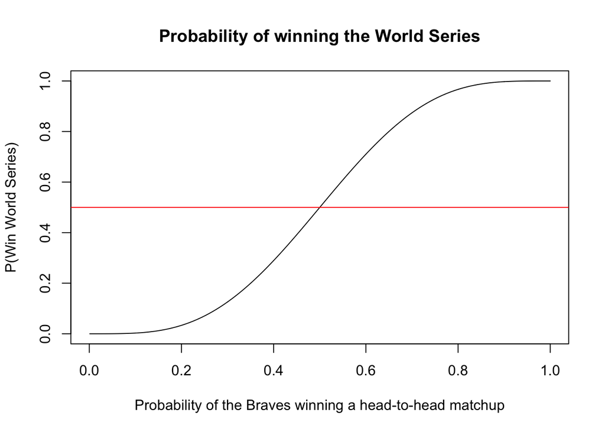

```r
x<-seq(0,1,by=0.001)
prob.win1<-pnbinom(3,4,x)
plot(x,prob.win1,main="Probability of winning the World Series",
     xlab = "Probability of the Braves winning a head-to-head matchup",
     ylab = "P(Win World Series)",
     type = "l")
abline(h=0.5,col="red")
```

*The probability of the Braves winning a head-to-head matchup(P<sub>B</sub>) is x now, P<sub>B</sub> could be between 0 and 1, I also set the increment of as 0.001 to make the results more accurate. From this graphic we can see P<sub>B</sub> on the x-axis and P(Braves win World Series) on the y-axis, P(Braves win World Series) depends on the P<sub>B</sub>. When P<sub>B</sub> is smaller than 0.5, it is less likely for Braves win World Series. When P<sub>B</sub> is larger than 0.5, it is more likely for Braves win World Series. We can also see a clear growth trend when P<sub>B</sub> is larger than 0.2 and smaller than 0.8.*

### 0.3.3 3.Suppose one could change the World Series to be best-of-9 or some other best-of-X series. What is the shortest series length so that P(Braves win World Series| P<sub>B</sub>=0.55)≥0.8

*In this question, the series length is not defined and the series length should be an odd number. We already have the assumption: P<sub>B</sub>= 0.55.*

*To win the World Series, if it is best-of-9, the winner has to win 5 matches and lose 4 or fewer matches, if it is best-of-11, the winner has to win 6 matches and lose 5 or fewer matches. In this way, we can set the number of wins (numwin) and the number of loss (numloss) would be the number of wins minus 1 (numwin-1) or fewer.*

*We have calculated in question 1: when P<sub>B</sub>=0.55, the probability of Braves win World Series is 0.6083 which is less than 0.8. Thus, the shortest series length must be more than 7 and the least number of wins must be more than 4, so I will set the sequence of the number of wins as 4 to 100. I use `pnbinom` to calculate the probability of Braves win World Series. And the World Series length (len.ser) would be the number of wins (numwin) plus the number of loss (numloss).*

```r
numwin = seq(4,100,by=1)
numloss = numwin-1
probwins= pnbinom(numloss,numwin,0.55)
len.ser=numloss+numwin
len.ser[which(probwins>= 0.8)][1]
```

```
## [1] 71
```

*From the results, we can know when P(Braves win World Series| P<sub>B</sub>=0.55)≥0.8, the shortest World Series length is 71.*

*I also plot a graph.*

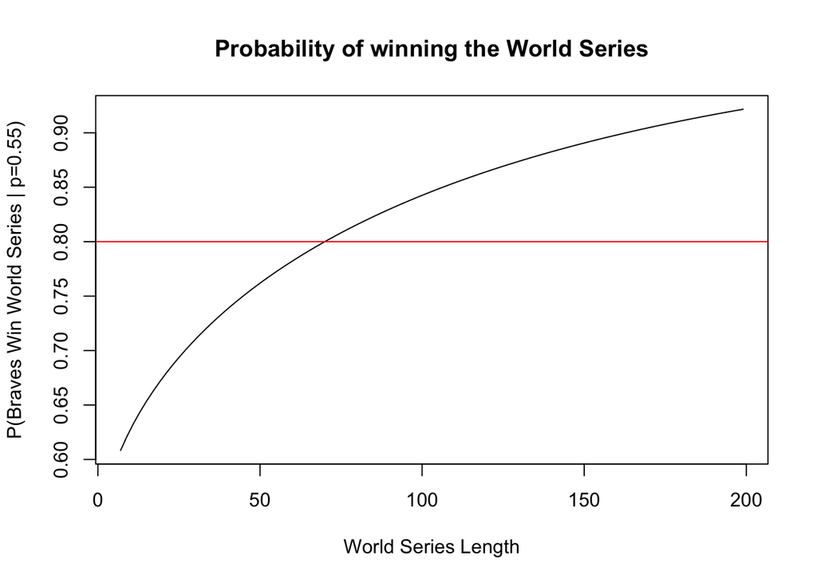

```r
plot(len.ser,probwins,
     main = "Probability of winning the World Series",
     xlab = "World Series Length",
     ylab = "P(Braves Win World Series | p=0.55)",
     type = "l")
abline(h=0.8,col="red")
```

*From this graph, we can see a clear positive correlation between World Series Length and P(Braves Win World Series|P<sub>B</sub>=0.55), and we can find the shortest length when P(Braves Win World Series| P<sub>B</sub>=0.55)>=0.8.*

### 0.3.4 4.What is the shortest series length so that P(Braves win World Series| P<sub>B</sub>=x) ≥ 0.8? This will be a figure (see below) with P<sub>B</sub> on the x-axis and series length is the y-axis.

*In this question, both P<sub>B</sub> and world series length have not be defined, so I would assume P<sub>B</sub> could be any number from 0.51 to 1 and the increment is 0.001. Then I create a for loop to record the series length and find the shortest length.*

```r
probbwin = seq(0.51,1,by=0.001)
shortlen = NA
for(i in 1:length(probbwin)){
  num.win=seq(1,100,by=1)
  num.loss=num.win-1
  pws=pnbinom(num.loss,num.win,probbwin[i])
  len.ser=num.win+num.loss
  shortlen[i]= len.ser[which(pws>=0.8)[1]]
}
```

*Then, I will draw a figure to show the relationship.*

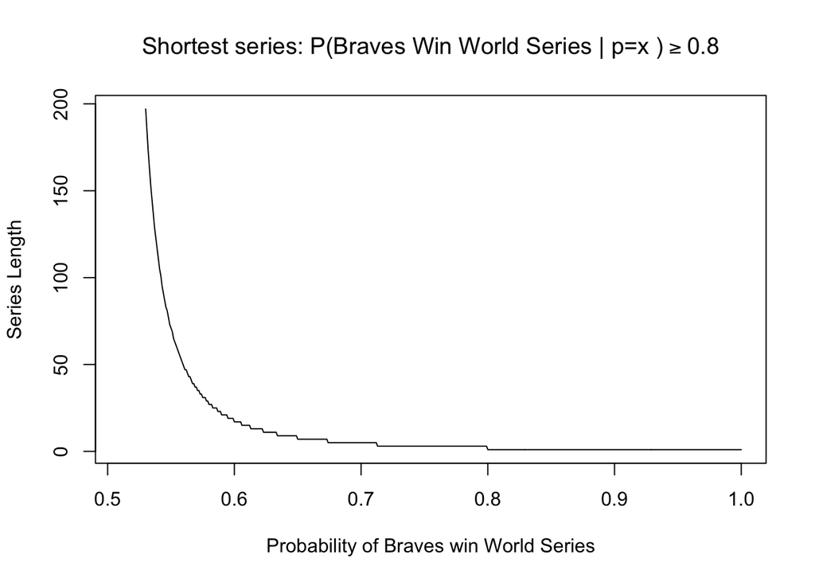

```r
plot(probbwin,shortlen,type = "l",
     main=expression("Shortest series: P(Braves Win World Series | p=x )">=0.8),
     xlab="Probability of Braves win World Series",
     ylab="Series Length")
```

*From this graph, we can see when P<sub>B</sub> is increasing, the shortest series length will decrease, when the probability of the Braves win the World Series is more than 0.8 and even approaching 1, the shortest series length is 1.*

### 0.3.5 5.Calculate P(P<sub>B</sub>=0.55|Braves win World Series in 7 games) under the assumption that either P<sub>B</sub>=0.55 or P<sub>B</sub>=0.45. Explain your solution.

*For this question, we should learn about Bayes’ theorem first:*
$$P(A|B)=\frac{P(B|A)P(A)}{P(B)}$$

*So, we have to calculate P(Braves win World Series in 7 games|P<sub>B</sub>=0.55), P(P<sub>B</sub>=0.55), P(Braves win World Series in 7 games).*

*From the question 1, we can get the P(Braves win World Series in 7 games|P<sub>B</sub>=0.55) = 0.1667701. And there is an assumption that either P<sub>B</sub>=0.55 or P<sub>B</sub>=0.45, so P(P<sub>B</sub>=0.55) = P(P<sub>B</sub>=0.45) = 0.5*

```r
#probability that Braves win the World Series in 7 games given that Pb=0.55
dnbinom(3,4,0.55)
```

```
## [1] 0.1667701
```

*Then, based on the assumption that either P<sub>B</sub>=0.55 or P<sub>B</sub>=0.45, we can calculate the P(Braves win World Series in 7 games) = P(Braves win World Series in 7 games|P<sub>B</sub>=0.55)xP(P<sub>B</sub>=0.55)+P(Braves win World Series in 7 games|P<sub>B</sub>=0.45)xP(P<sub>B</sub>=0.45) = 0.1516092*

```r
#P(Braves win World Series in 7 games)
dnbinom(3,4,0.45)*0.5+dnbinom(3,4,0.55)*0.5
```

```
## [1] 0.1516092
```

*Finally, we can solve the problem using Bayes’ formula and get the answer 0.55*

```r
#P(Pb=0.55|Braves win World Series in 7 games) under the assumption that either Pb=0.55 or Pb=0.45
dnbinom(3,4,0.55)*0.5/(dnbinom(3,4,0.45)*0.5+dnbinom(3,4,0.55)*0.5)
```

```
## [1] 0.55
```